# Wisconsin Economic Trends

Dawson Gronemus

2025-08-23

Abstract

This report analyzes key economic indicators for the state of Wisconsin from 2000 to the present using public data from the Federal Reserve Economic Database (FRED). Metrics include the unemployment rate, real GDP growth (compared to the U.S.), and average weekly earnings (both nominal and inflation-adjusted). The goal is to provide a concise yet comprehensive snapshot of Wisconsin’s economy and highlight long-term trends in employment, output, and wages.

# Setup

First, install and load the required packages:

```r
#install.packages(c("fredr", "tidyverse", "lubridate"), repos = #"http://cran.us.r-project.org")

library(fredr)
library(tidyverse)
library(lubridate)

# Load API key from environment variable
fredr_set_key(Sys.getenv("FRED_API_KEY"))
```

# Unemployment

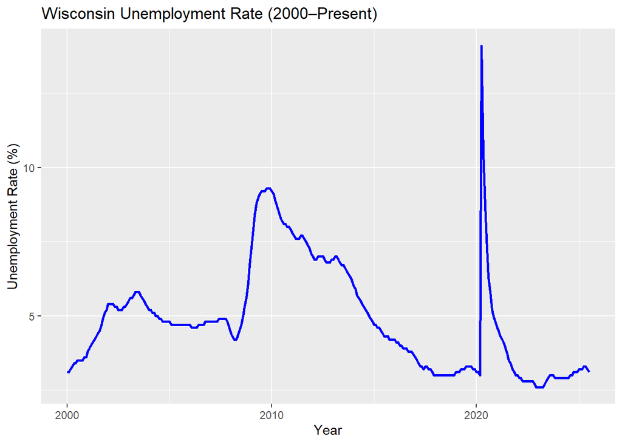

```r
wi_unemp <- fredr(
  series_id = "WIUR",   # Wisconsin Unemployment Rate
  observation_start = as.Date("2000-01-01")
)

wi_unemp %>%
  ggplot(aes(x = date, y = value)) +
  geom_line(color = "blue", linewidth = 1) +
  labs(
    title = "Wisconsin Unemployment Rate (2000–Present)",
    x = "Year", y = "Unemployment Rate (%)"
  )
```

# GDP

[figure not shown]

```r
# Wisconsin Real GDP (quarterly, millions of chained 2017 dollars → convert to billions)
wi_gdp <- fredr(
  series_id = "WIRQGSP",
  observation_start = as.Date("2000-01-01")
) %>%
  mutate(value_bil = value / 1000, region = "Wisconsin")

# U.S. Real GDP (already billions of chained 2017 dollars)
us_gdp <- fredr(
  series_id = "GDPC1",
  observation_start = as.Date("2000-01-01")
) %>%
  mutate(value_bil = value, region = "United States")

# Normalize both to 100 at start
wi_gdp <- wi_gdp %>%
  mutate(value_index = (value_bil / first(value_bil)) * 100)

us_gdp <- us_gdp %>%
  mutate(value_index = (value_bil / first(value_bil)) * 100)

# Combine datasets
gdp_data <- bind_rows(wi_gdp, us_gdp)

# Plot with legend
ggplot(gdp_data, aes(x = date, y = value_index, color = region, linetype = region)) +
  geom_line(linewidth = 1.2) +
  scale_color_manual(values = c("Wisconsin" = "darkgreen", "United States" = "gray40")) +
  scale_linetype_manual(values = c("Wisconsin" = "solid", "United States" = "dashed")) +
  labs(
    title = "Wisconsin vs U.S. Real GDP Growth (2000–Present)",
    subtitle = "Indexed to 100 at 2000 = relative growth comparison",
    x = "Year",
    y = "Real GDP Growth (2000 = 100, Inflation-Adjusted)",
    color = "Region",
    linetype = "Region"
  ) +
  # Annotation to explain axis meaning
  annotate("text",
           x = as.Date("2005-01-01"), y = 220,
           label = "100 = GDP in 2000\n150 = 50% growth\n200 = doubled since 2000",
           hjust = 0, vjust = 1, size = 3.5, color = "black") +
  theme_minimal()
```

# Nominal vs. Real Wages

The first chart shows **nominal average weekly earnings** in Wisconsin.  
- These are the raw dollar amounts workers received each week.  
- Nominal wages almost always look like they’re rising, because they don’t account for inflation.

The second chart shows **real average weekly earnings**, which are **adjusted for inflation using the Consumer Price Index (CPI)**.  
- Real wages tell us about **purchasing power** — how much workers can actually buy with their wages.  
- This view shows that while dollar amounts went up, the actual **buying power of wages has grown much more slowly**, and in some years even declined.

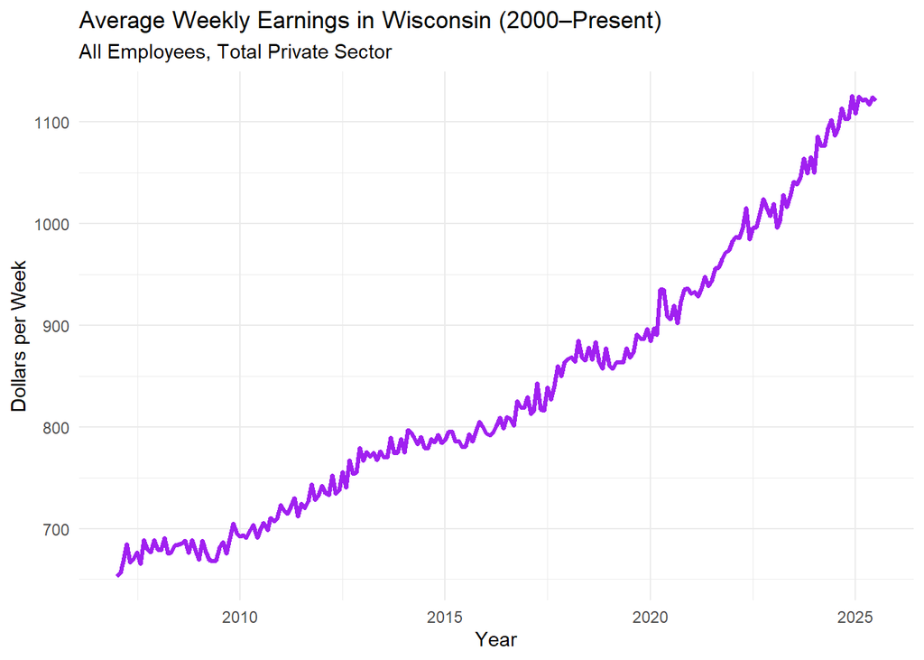

```r
# Wisconsin Average Weekly Earnings (Total Private)
wi_wages <- fredr(
  series_id = "SMU55000000500000011",
  observation_start = as.Date("2000-01-01")
)

# Plot
wi_wages %>%
  ggplot(aes(x = date, y = value)) +
  geom_line(color = "purple", linewidth = 1.2) +
  labs(
    title = "Average Weekly Earnings in Wisconsin (2000–Present)",
    subtitle = "All Employees, Total Private Sector",
    x = "Year",
    y = "Dollars per Week"
  ) +
  theme_minimal()
```

[figure not shown]

```r
# CPI series (monthly, seasonally adjusted)
cpi <- fredr(
  series_id = "CPIAUCSL",
  observation_start = as.Date("2000-01-01")
)

# Join wages + CPI by date
wi_wages_real <- wi_wages %>%
  left_join(cpi %>% select(date, cpi = value), by = "date") %>%
  mutate(real_wage = value / (cpi / first(cpi)))   # normalize to 2000 CPI

# Plot Real Wages
wi_wages_real %>%
  ggplot(aes(x = date, y = real_wage)) +
  geom_line(color = "darkorange", linewidth = 1.2) +
  labs(
    title = "Real Average Weekly Earnings in Wisconsin (2000–Present)",
    subtitle = "Inflation-adjusted using CPI (2000 = 100)",
    x = "Year",
    y = "Dollars per Week (2017 Dollars)"
  ) +
  theme_minimal()
```

# Conclusion: Wisconsin Economic Snapshot (2000–Present)

**Unemployment:**  
- Clear spikes during the **2008–09** recession and **2020** pandemic, followed by recoveries.  
- The latest readings are low by historical standards, signaling a tight labor market.

**Wages:**  
- **Nominal** wages rise steadily over time.  
- **Real** wages (inflation-adjusted) grow **much more slowly** and exhibit plateaus/declines around recessions and the 2021–22 inflation surge, meaning **purchasing power** gains are modest.

### Limitations & Next Steps

- Series are state-level aggregates; county/metro differences could be large.
- Consider adding:
  - **County comparisons** (La Crosse, Dane, Milwaukee) for within-state variation.
  - **Sector breakdowns** (manufacturing vs. services).
  - **Per-capita** adjustments (GDP per capita, real wages by hours).
  - **Labor force participation** and **employment-population ratio** for depth.
- Build a **Shiny dashboard** to interactively switch metrics/regions and export charts.

# References

- Federal Reserve Bank of St. Louis, *FRED Economic Data*.
  - Wisconsin Unemployment Rate (WIUR)
  - Real Gross Domestic Product: Wisconsin (WIRQGSP)
  - Real Gross Domestic Product: United States (GDPC1)
  - Average Weekly Earnings of All Employees: Total Private in Wisconsin (SMU55000000500000011)
  - Consumer Price Index for All Urban Consumers: All Items (CPIAUCSL)  
    Retrieved from: https://fred.stlouisfed.org